# R Notebook

Process : 1. Assign cells with BMMap (CellType_Broad) NB : run BMMap with raw counts

### clean environment

```r
rm(list=ls())
```

### set directory

```r
    knitr::opts_knit$set(root.dir = normalizePath("/home/flomik/Code/MOFA_AML/"))
```

```r
library(BoneMarrowMap)
library(Seurat)
library(dplyr)
library(ggplot2)
library(readxl)
library(data.table)
```

## Load Symphony reference

```r
ref <- readRDS("~/Data/CITE_seq/BoneMarrowMap-main/BoneMarrowMap_SymphonyReference.rds")
#ref <- readRDS("/home/flomik/Data/CITE_seq/BoneMarrowMap/BoneMarrowMap_SymphonyReference.rds")
ref$save_uwot_path <- paste0("~/Data/CITE_seq/BoneMarrowMap-main/", 'BoneMarrowMap_uwot_model.uwot')
#ref$save_uwot_path <- paste0("~/Data/CITE_seq/BoneMarrowMap/", 'BoneMarrowMap_uwot_model.uwot')
```

## load seurat object

```r
#data <- readRDS("/home/flomik/Data/CITE_seq/Wells_combined_sctransformed.rds")
data <- readRDS("/home/flomik/Data/Clinseq/CITE_seq/Wells_combined_sctransformed.rds")
data
```

```
An object of class Seurat
44754 features across 17867 samples within 5 assays
Active assay: integrated (3000 features, 3000 variable features)
 2 layers present: data, scale.data
 4 other assays present: RNA, HTO, ADT, SCT
 3 dimensional reductions calculated: pca, umap, tsne
```

## remove allographs, CD4 and APL samples

```r
Idents(data) <- "PatientLevel"
all_samples <- factor(data$PatientLevel)
x <- levels(all_samples)
x <- x[-c(1:3)]
data <- subset(data, idents = x)
```

## assign AML cell types to cells

```r
batchvar <- "PatientLevel"
# Map query dataset using Symphony (Kang et al 2021)
query <- map_Query(
    exp_query = LayerData(data, assay = "RNA", layer = "counts"),
    metadata_query = data@meta.data,
    ref_obj = ref,
    vars = batchvar
    )
```

```
Normalizing
Scaling and synchronizing query gene expression
Found 2361 reference variable genes in query dataset
Project query cells using reference gene loadings
Clustering query cells to reference centroids
Correcting query batch effects
UMAP
All done!
```

```r
ncol(query)
```

```
[1] 17468
```

## filter out low quality cells

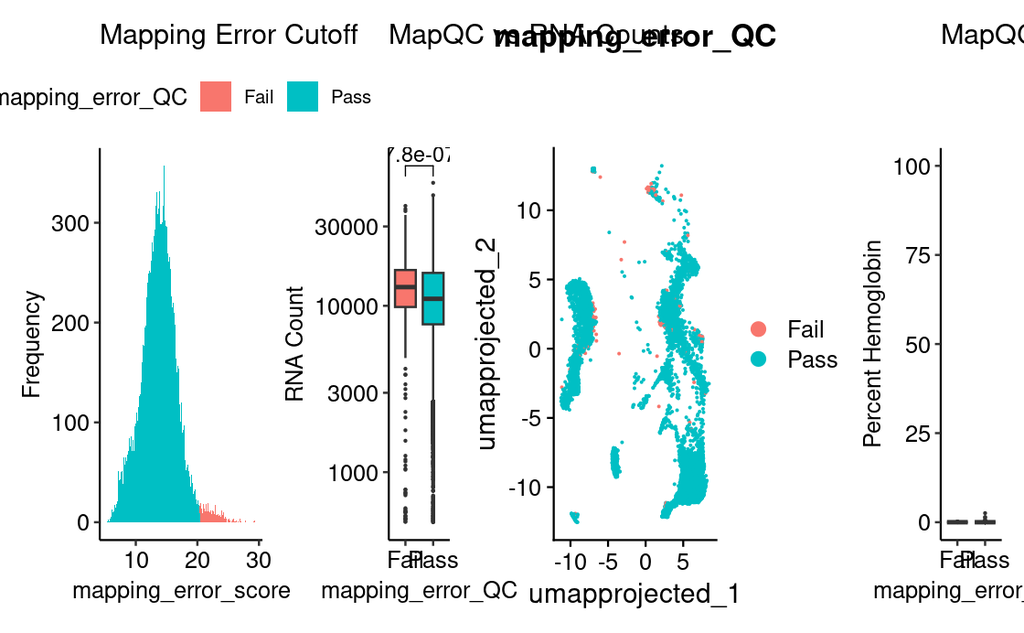

```r
# Run QC based on mapping error score, flag cells with mapping error >= 2.5 MADs above median
query <- query %>% calculate_MappingError(., reference = ref, MAD_threshold = 2.5)

# Get QC Plots
QC_plots <- plot_MappingErrorQC(query)
# Plot together - If this is too crowded, can also just call "QC_plots" aloneto display one by one
patchwork::wrap_plots(QC_plots, ncol = 4, widths = c(0.8, 0.3, 0.8, 0.3))
```

```r
# # Optional step - remove outliers with high mapping error
query <- subset(query, mapping_error_QC == 'Pass')

ncol(query)
```

```
[1] 17062
```

```r
nrow(query)
```

```
[1] 22254
```

HSC MPP — #E8A020 (medium orange) LMPP — #F5C842 (golden yellow) Cycling Progenitor — #F5E070 (pale yellow) Early GMP — #FAEFC0 (very pale yellow/cream) Megakaryo-Erythroid lineage

MEP — #8B0000 (dark red / burgundy) Megakaryocyte Precursor — #CC2200 (strong red) Early Erythroid — #E8604A (salmon-red) Late Erythroid — #F0A090 (light salmon/pink) Innate myeloid cells

EoBasoMast Precursor — #1A3A6B (dark navy blue) Pro-Monocyte — #2E6FAD (medium-dark blue) Monocyte — #4A9FD4 (medium blue) cDC — #7DC0E8 (light-medium blue) pDC — #AADDF5 (pale blue) Stromal — #D0EEF8 (very pale blue) Lymphoid lineage

Early Lymphoid — #1A1A1A (near black) Pro-B — #505050 (dark grey) Pre-B — #787878 (medium grey) B — #A0A0A0 (medium-light grey) Plasma_Cell — #C8C8C8 (light grey) NK — #E8E8E8 (very light grey)

```r
col <- c("#A0A0A0", # B
         "#BAE4B3", # CD4 T
         "#74C476", # CD8 T
         "#7DC0E8", # cDC
         "#F5E070", # Cycling Progenitor
         "#E8604A", # Early Erythroid
         "#FAEFC0", # Early GMP
         "#1A1A1A", # Early Lymphoid
         "#1A3A6B", # EoBasoMast Precursor
         "#E8A020", # HSC MPP
         "#F0A090", # Late Erythroid
         "#f7e391", # Late GMP
         "#F5C842", # LMPP
         "#CC2200", # Megakaryocyte Precursor
         "#8B0000", # MEP
         "#4A9FD4", # Monocyte
         "#EDF8E9", # Naive T
         "#E8E8E8", # NK
         "#AADDF5", # pDC
         "#C8C8C8", # Plasma_Cell
         "#787878", # Pre-B
         "#505050", # Pro-B
         "#2E6FAD", # Pro-Monocyte
         "#D0EEF8" # Stromal
         )
```

## Predict Hematopoietic Cell Types by KNN classification

```r
query <- predict_CellTypes(
  query_obj = query,
  ref_obj = ref,
  initial_label = 'initial_CellType', # celltype assignments before filtering on mapping QC
  final_label = 'predicted_CellType'  # celltype assignments with map QC failing cells assigned as NA
)
```

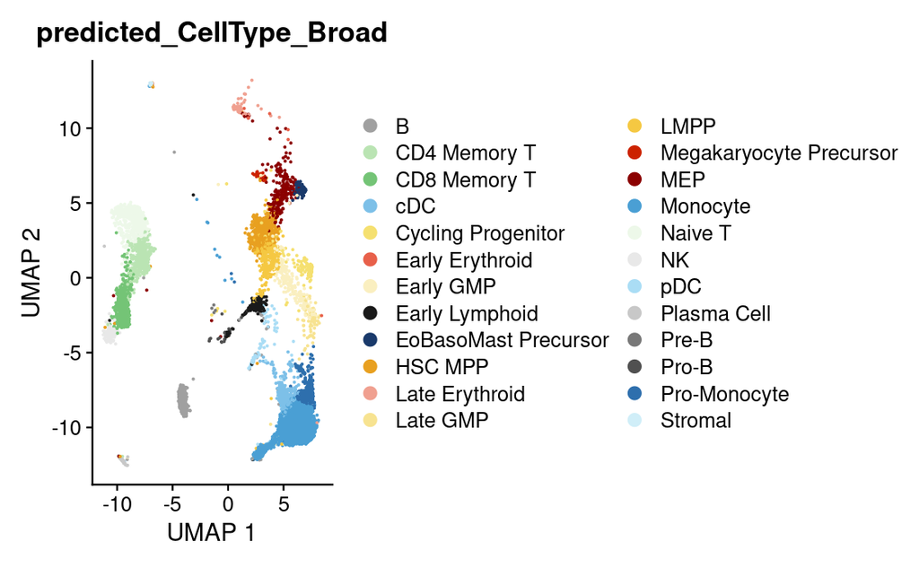

```r
DimPlot(query, reduction = 'umap_projected', group.by = c('predicted_CellType_Broad'),
        raster=FALSE, label=FALSE, label.size = 4, cols = col) + xlab("UMAP 1")+ylab("UMAP 2")

ggsave(paste0("results/figures/scRNA/KI/score_plot_predicted_cell_types_BMmap_prospective_KI.pdf"), width = 9, height = 4)
```

# Predict Pseudotime values by KNN

query <- predict_Pseudotime( query_obj = query, ref_obj = ref, initial_label = ‘initial_Pseudotime’, # pseudotime assignments before filtering on mapping QC final_label = ‘predicted_Pseudotime’ # pseudotime assignments with map QC failing cells assigned as NA )

# Visualize Hematopoietic Pseudotime in query data

FeaturePlot(query, features = c(‘predicted_Pseudotime’))

ggsave(paste0(“results/figures/scRNA/KI/score_plot_predicted_pseudotime_BMmap_prospective_KI.pdf”), width = 5, height = 3.5)

```r
saveRDS(query, "/home/flomik/Data/CITE_seq/Seurat_object_predicted_class_BMmap_KI_v2.rds")
```

## calculate factors for each cell

```r
#' Perform survival analysis for each MOFA factor
#'
#' @param file variable containing file
#' @param name name of the file
#' @param destination destination folder for file
scores_factor <- function(fname, txn, genes){
  myFactor1=RNAfac[RNAfac$factor==fname,]
  p1=c(1:nrow(myFactor1)) # for coefficients

  if(genes == "genes"){
    myFactor1$feature <- myFactor1$label
  }

  pick=txn$stable_id %in% myFactor1$feature[p1]
  #print(pick)
  mygex1=txn[pick,drop=FALSE,]
  rownames(mygex1) <- mygex1$stable_id
  mygex1=data.frame(t(mygex1[,colnames(mygex1) != "stable_id"]))
  x=as.matrix(mygex1)
  #print(dim(x))

  beta=myFactor1$value[match(colnames(x),myFactor1$feature)]
  beta[is.na(beta)] <- 0
  yval=t(t(x) * beta)
  yval=rowSums(yval)

  weight <- data.frame(yval)
  colnames(weight) <- fname
  weight$patient_id <- rownames(weight)

  yval <- data.frame(patient_id = names(yval), score = yval)
  yval$group <- as.integer(yval$score > median(yval$score))+1
  return(yval)
}
```

```r
gex <- as.data.frame(query@assays$RNA$scale.data)
gex$stable_id <- rownames(gex)
#gex$stable_id <- gsub("\\..*", "", gex$stable_id)
#gex <- aggregate(. ~ stable_id, data = gex, sum)
#rownames(gex) <- gex$stable_id
```